# Role structure in multiplex networks

Algebraic analysis of complex social networks* Networks 2021 Conference – Workshop 8 (part 3)

Antonio Rivero Ostoic

Sch Culture & Soc, Aarhus University

jaro@cas.au.dk

24 June 2021

Directed multiplex networks are complex structures.

## Incubator network A

An example of multiplex network is found in *Incubator network A*, which is a dataset in `"multiplex"` package.

```r
# load data for Incubator network A
data(incA)
```

```r
# data structure in object 'incA'
str(incA)
```

```
List of 5
 $ net  : num [1:26, 1:26, 1:5] 0 0 0 0 0 0 0 0 0 1 ...
  ..- attr(*, "dimnames")=List of 3
  .. ..$ : chr [1:26] "5" "6" "9" "12" ...
  .. ..$ : chr [1:26] "5" "6" "9" "12" ...
  .. ..$ : chr [1:5] "C" "F" "K" "A" ...
 $ atnet:List of 1
  ..$ : num [1:5] 0 0 0 1 1
 $ IM   : num [1:4, 1:4, 1:7] 1 1 1 0 0 1 0 0 1 0 ...
  ..- attr(*, "dimnames")=List of 3
  .. ..$ : NULL
  .. ..$ : NULL
  .. ..$ : chr [1:7] "C" "F" "K" "D" ...
 $ atIM : num [1:7] 0 0 0 0 0 0 1
 $ cite :List of 1
  ..$ : 'noquote' chr [1:4] "Incubator network A (version 2). " " 'net' for Friendship, Collaboration, and Competition ties and two actor attributes " " 'IM' are their Image Matrices with transposes and a single attribute " " 'atnet' and 'atIM' indicate whether or not the array represents attribute …
 - attr(*, "class")= chr "Data.Set"
```

### Plotting

```r
# redefine node / edge / graph characteristics
R> scp <- list(cex=3, ecol=c("green","orange","red"), lwd=2, vcol="#3399FF",
+    vcol0="#808080", bwd=.5, pos=0, fsize=8, rot=-75, mirrorX=TRUE)
```

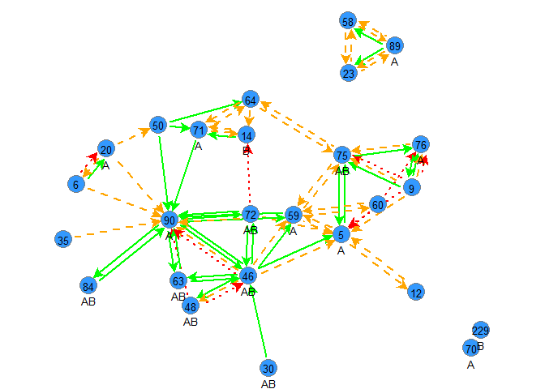

Multigraph of Incubator network A with actor attributes

```r
# plot multigraph of 'incA' with force directed layout
multigraph(incA, layout="force", seed=22, scope=scp)
```

## Positional analysis

Start by constructing the of Incubator A with transpose relations and actor attributes

```r
# by default k=3 where NA in 'tlbs' prevent tie transposition
rb_A <- rbox(incA$net, transp=TRUE, tlbs=c("D", "G", "L", NA, NA))
```

```r
# data structure in 'rb_A'
str(rb_A)
```

```
List of 7
 $ w    : num [1:26, 1:26, 1:8] 0 0 0 0 0 0 0 0 0 1 ...
  ..- attr(*, "dimnames")=List of 3
  .. ..$ : NULL
  .. ..$ : NULL
  .. ..$ : chr [1:8] "C" "F" "K" "A" ...
 $ W    : num [1:26, 1:26, 1:584] 0 0 0 0 0 0 0 0 0 1 ...
  ..- attr(*, "dimnames")=List of 3
  .. ..$ : NULL
  .. ..$ : NULL
  .. ..$ : chr [1:584] "C" "F" "K" "A" ...
 $ lbs  : chr [1:26] "5" "6" "9" "12" ...
 $ Note : chr "Transpose relations are included"
 $ Trels: chr [1:3] "D" "G" "L"
 $ k    : num 3
 $ z    : int 584
 - attr(*, "class")= chr "Rel.Box"
```

### Cumulated Person Hierarchy

The Cumulated Person Hierarchy of the above Relation-Box with function `cph()`.

```r
# must be a "Rel.Box" class object
cph_A <- cph(rb_A)
```

```
    5 6 9 12 14 20 23 30 35 46 48 50 58 59 60 63 64 70 71 72 75 76 84 89 90 229
5   1 0 0  0  0  0  0  0  0  0  0  0  0  0  0  0  0  0  0  0  0  0  0  0  0   0
6   1 1 1  1  1  1  0  0  1  1  1  1  0  1  1  1  1  0  1  1  1  1  1  0  1   0
9   1 0 1  1  1  0  0  0  0  1  1  1  0  1  1  1  1  0  1  1  1  1  1  0  1   0
12  1 0 1  1  1  0  0  0  0  1  1  1  0  1  1  1  1  0  1  1  1  1  1  0  1   0
14  1 0 1  1  1  0  0  0  0  1  1  1  0  1  1  1  1  0  1  1  1  1  1  0  1   0
20  1 1 1  1  1  1  0  0  1  1  1  1  0  1  1  1  1  0  1  1  1  1  1  0  1   0
23  0 0 0  0  0  0  1  0  0  0  0  0  1  0  0  0  0  0  0  0  0  0  0  0  0   0
30  1 0 1  1  1  0  0  1  0  1  1  1  0  1  1  1  1  0  1  1  1  1  1  0  1   0
35  1 1 1  1  1  1  0  0  1  1  1  1  0  1  1  1  1  0  1  1  1  1  1  0  1   0
46  0 0 0  0  0  0  0  0  0  1  0  0  0  0  0  0  0  0  0  0  0  0  0  0  0   0
48  0 0 0  0  0  0  0  0  0  1  1  0  0  0  0  0  0  0  0  0  0  0  0  0  0   0
50  1 0 1  1  1  0  0  0  0  1  1  1  0  1  1  1  1  0  1  1  1  1  1  0  1   0
58  0 0 0  0  0  0  1  0  0  0  0  0  1  0  0  0  0  0  0  0  0  0  0  0  0   0
59  0 0 0  0  0  0  0  0  0  0  0  0  0  1  0  0  0  0  0  0  0  0  0  0  0   0
60  1 0 1  1  1  0  0  0  0  1  1  1  0  1  1  1  1  0  1  1  1  1  1  0  1   0
63  1 0 1  1  1  0  0  0  0  1  1  1  0  1  1  1  1  0  1  1  1  1  1  0  1   0
64  1 0 0  0  0  0  0  0  0  0  0  0  0  1  0  0  1  0  0  0  0  0  0  0  0   0
70  0 0 0  0  0  0  0  0  0  0  0  0  0  0  0  0  0  1  0  0  0  0  0  0  0   0
71  1 0 1  1  1  0  0  0  0  1  1  1  0  1  1  1  1  0  1  1  1  1  1  0  1   0
72  1 0 1  1  1  0  0  0  0  1  1  1  0  1  1  1  1  0  1  1  1  1  1  0  1   0
75  1 0 1  1  1  0  0  0  0  1  1  1  0  1  1  1  1  0  1  1  1  1  1  0  1   0
76  1 0 1  1  1  0  0  0  0  1  1  1  0  1  1  1  1  0  1  1  1  1  1  0  1   0
84  1 0 1  1  1  0  0  0  0  1  1  1  0  1  1  1  1  0  1  1  1  1  1  0  1   0
89  0 0 0  0  0  0  0  0  0  0  0  0  0  0  0  0  0  0  0  0  0  0  0  1  0   0
90  0 0 0  0  0  0  0  0  0  0  0  0  0  0  0  0  0  0  0  0  0  0  0  0  1   0
229 0 0 0  0  0  0  0  0  0  0  0  0  0  0  0  0  0  0  0  0  0  0  0  0  0   1
attr(,"class")
[1] "Partial.Order" "CPH"
```

To plot the lattice diagram of the cumulated person hierarchy of Incubator network A, we use function `diagram()` that requires package `"Rgraphviz"`.

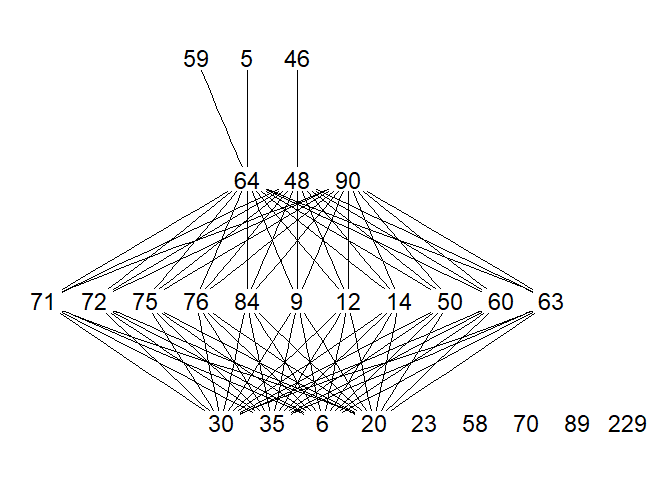

Inclusion lattice of cumulated person hierarchy

```r
# avoid info about dependencies, masking, etc
require(Rgraphviz, quietly=TRUE)
diagram(cph_A)
```

The partially ordered set in a matrix format.

```r
# permute poset of the CPH of 'incA'
perm(cph_A, clu=c(1,2,3,3,3,2,4,2,2,1,1,3,4,1,3,3,1,4,3,3,3,3,3,4,1,4))
```

```
    5 46 48 59 64 90 6 20 30 35 9 12 14 50 60 63 71 72 75 76 84 23 58 70 89 229
5   1  0  0  0  0  0 0  0  0  0 0  0  0  0  0  0  0  0  0  0  0  0  0  0  0   0
46  0  1  0  0  0  0 0  0  0  0 0  0  0  0  0  0  0  0  0  0  0  0  0  0  0   0
48  0  1  1  0  0  0 0  0  0  0 0  0  0  0  0  0  0  0  0  0  0  0  0  0  0   0
59  0  0  0  1  0  0 0  0  0  0 0  0  0  0  0  0  0  0  0  0  0  0  0  0  0   0
64  1  0  0  1  1  0 0  0  0  0 0  0  0  0  0  0  0  0  0  0  0  0  0  0  0   0
90  0  0  0  0  0  1 0  0  0  0 0  0  0  0  0  0  0  0  0  0  0  0  0  0  0   0
6   1  1  1  1  1  1 1  1  0  1 1  1  1  1  1  1  1  1  1  1  1  0  0  0  0   0
20  1  1  1  1  1  1 1  1  0  1 1  1  1  1  1  1  1  1  1  1  1  0  0  0  0   0
30  1  1  1  1  1  1 0  0  1  0 1  1  1  1  1  1  1  1  1  1  1  0  0  0  0   0
35  1  1  1  1  1  1 1  1  0  1 1  1  1  1  1  1  1  1  1  1  1  0  0  0  0   0
9   1  1  1  1  1  1 0  0  0  0 1  1  1  1  1  1  1  1  1  1  1  0  0  0  0   0
12  1  1  1  1  1  1 0  0  0  0 1  1  1  1  1  1  1  1  1  1  1  0  0  0  0   0
14  1  1  1  1  1  1 0  0  0  0 1  1  1  1  1  1  1  1  1  1  1  0  0  0  0   0
50  1  1  1  1  1  1 0  0  0  0 1  1  1  1  1  1  1  1  1  1  1  0  0  0  0   0
60  1  1  1  1  1  1 0  0  0  0 1  1  1  1  1  1  1  1  1  1  1  0  0  0  0   0
63  1  1  1  1  1  1 0  0  0  0 1  1  1  1  1  1  1  1  1  1  1  0  0  0  0   0
71  1  1  1  1  1  1 0  0  0  0 1  1  1  1  1  1  1  1  1  1  1  0  0  0  0   0
72  1  1  1  1  1  1 0  0  0  0 1  1  1  1  1  1  1  1  1  1  1  0  0  0  0   0
75  1  1  1  1  1  1 0  0  0  0 1  1  1  1  1  1  1  1  1  1  1  0  0  0  0   0
76  1  1  1  1  1  1 0  0  0  0 1  1  1  1  1  1  1  1  1  1  1  0  0  0  0   0
84  1  1  1  1  1  1 0  0  0  0 1  1  1  1  1  1  1  1  1  1  1  0  0  0  0   0
23  0  0  0  0  0  0 0  0  0  0 0  0  0  0  0  0  0  0  0  0  0  1  1  0  0   0
58  0  0  0  0  0  0 0  0  0  0 0  0  0  0  0  0  0  0  0  0  0  1  1  0  0   0
70  0  0  0  0  0  0 0  0  0  0 0  0  0  0  0  0  0  0  0  0  0  0  0  1  0   0
89  0  0  0  0  0  0 0  0  0  0 0  0  0  0  0  0  0  0  0  0  0  0  0  0  1   0
229 0  0  0  0  0  0 0  0  0  0 0  0  0  0  0  0  0  0  0  0  0  0  0  0  0   1
```

### Positional system

To produce its positional system, we reduce generator relations in `incA`, which is a component of the Relation-Box in `rb_A` with the clustering information

```r
# reduce matrices in Incubator network A
ps_A <- reduc(rb_A$w, clu=c(3,2,1,1,1,2,4,2,2,3,3,1,4,3,1,1,3,4,1,1,1,1,1,4,3,4))
```

```
, , C

     [,1] [,2] [,3] [,4]
[1,]    1    0    1    0
[2,]    0    1    1    0
[3,]    1    0    1    0
[4,]    0    0    0    1

, , F

     [,1] [,2] [,3] [,4]
[1,]    1    0    1    0
[2,]    1    1    1    0
[3,]    1    0    1    0
[4,]    0    0    0    1

, , K

     [,1] [,2] [,3] [,4]
[1,]    1    0    1    0
[2,]    0    1    0    0
[3,]    0    0    1    0
[4,]    0    0    0    0

, , A

     [,1] [,2] [,3] [,4]
[1,]    1    0    0    0
[2,]    0    1    0    0
[3,]    0    0    1    0
[4,]    0    0    0    1

, , B

     [,1] [,2] [,3] [,4]
[1,]    1    0    0    0
[2,]    0    1    0    0
[3,]    0    0    1    0
[4,]    0    0    0    1

```

[output cut: 8 more lines]

```
, , G

     [,1] [,2] [,3] [,4]
[1,]    1    1    1    0
[2,]    0    1    0    0
[3,]    1    1    1    0
[4,]    0    0    0    1

, , L

     [,1] [,2] [,3] [,4]
[1,]    1    0    0    0
[2,]    0    1    0    0
[3,]    1    0    1    0
[4,]    0    0    0    0
```

### Role structure

The role structure is represented by a partially ordered semigroup where the multiplication table that represents the semigroup structure and the partial order table is built from the string *role* relations.

Function `semigroup()` produces the multiplication table either with a `"numeric"` or a `"symbolic"` format.

```r
# role structure from positional system
S_A <- semigroup(ps_A, type="symbolic")
```

```
      C   F   K   A   D   G   L  CK  CD  CL  KD  KL  DC  DF  DK  GC CKD KDC DCK DCL
C     F   F  CK   C  CD  CD  CL  CL  CD  CL CKD  CL  CD  CD CKD  CD CKD CKD CKD CKD
F     F   F  CL   F  CD  CD  CL  CL  CD  CL CKD  CL  CD  CD CKD  CD CKD CKD CKD CKD
K    CK  CL   K   K  KD  KD  KL  CK CKD  CL  KD  KL KDC CKD  KD KDC CKD KDC KDC CKD
A     C   F   K   A   D   G   L  CK  CD  CL  KD  KL  DC  DF  DK  GC CKD KDC DCK DCL
D    DC  DF  DK   D   G   G  DK DCK  CD DCL  KD  DK  GC  CD  KD  GC CKD KDC KDC CKD
G    GC  CD  KD   G   G   G  KD KDC  CD CKD  KD  KD  GC  CD  KD  GC CKD KDC KDC CKD
L    CK  CL  KL   L  DK  KD   L  CK CKD  CL  KD  KL DCK DCL  DK KDC CKD KDC DCK DCL
CK   CL  CL  CK  CK CKD CKD  CL  CL CKD  CL CKD  CL CKD CKD CKD CKD CKD CKD CKD CKD
CD   CD  CD CKD  CD  CD  CD CKD CKD  CD CKD CKD CKD  CD  CD CKD  CD CKD CKD CKD CKD
CL   CL  CL  CL  CL CKD CKD  CL  CL CKD  CL CKD  CL CKD CKD CKD CKD CKD CKD CKD CKD
KD  KDC CKD  KD  KD  KD  KD  KD KDC CKD CKD  KD  KD KDC CKD  KD KDC CKD KDC KDC CKD
KL   CK  CL  KL  KL  KD  KD  KL  CK CKD  CL  KD  KL KDC CKD  KD KDC CKD KDC KDC CKD
DC   DF  DF DCK  DC  CD  CD DCL DCL  CD DCL CKD DCL  CD  CD CKD  CD CKD CKD CKD CKD
DF   DF  DF DCL  DF  CD  CD DCL DCL  CD DCL CKD DCL  CD  CD CKD  CD CKD CKD CKD CKD
DK  DCK DCL  DK  DK  KD  KD  DK DCK CKD DCL  KD  DK KDC CKD  KD KDC CKD KDC KDC CKD
GC   CD  CD KDC  GC  CD  CD CKD CKD  CD CKD CKD CKD  CD  CD CKD  CD CKD CKD CKD CKD
CKD CKD CKD CKD CKD CKD CKD CKD CKD CKD CKD CKD CKD CKD CKD CKD CKD CKD CKD CKD CKD
KDC CKD CKD KDC KDC CKD CKD CKD CKD CKD CKD CKD CKD CKD CKD CKD CKD CKD CKD CKD CKD
DCK DCL DCL DCK DCK CKD CKD DCL DCL CKD DCL CKD DCL CKD CKD CKD CKD CKD CKD CKD CKD
DCL DCL DCL DCL DCL CKD CKD DCL DCL CKD DCL CKD DCL CKD CKD CKD CKD CKD CKD CKD CKD
```

```r
# partial order of string role relations
P_A <- partial.order(strings(ps_A))
```

```
    C F K A D G L CK CD CL KD KL DC DF DK GC CKD KDC DCK DCL
C   1 1 0 0 0 0 0  0  1  0  0  0  1  1  0  1   0   0   0   0
F   0 1 0 0 0 0 0  0  1  0  0  0  0  1  0  0   0   0   0   0
K   1 1 1 0 1 1 0  1  1  1  1  1  1  1  1  1   1   1   1   1
A   1 1 0 1 1 1 0  0  1  0  0  0  1  1  0  1   0   0   0   0
D   0 0 0 0 1 1 0  0  1  0  0  0  1  1  0  1   0   0   0   0
G   0 0 0 0 0 1 0  0  1  0  0  0  0  0  0  1   0   0   0   0
L   1 1 0 0 1 1 1  1  1  1  1  1  1  1  1  1   1   1   1   1
CK  1 1 0 0 0 0 0  1  1  1  0  0  1  1  0  1   1   1   1   1
CD  0 0 0 0 0 0 0  0  1  0  0  0  0  0  0  0   0   0   0   0
CL  0 1 0 0 0 0 0  0  1  1  0  0  0  1  0  0   1   0   0   1
KD  0 0 0 0 0 1 0  0  1  0  1  0  0  0  0  1   1   1   0   0
KL  1 1 0 0 1 1 0  1  1  1  1  1  1  1  1  1   1   1   1   1
DC  0 0 0 0 0 0 0  0  1  0  0  0  1  1  0  1   0   0   0   0
DF  0 0 0 0 0 0 0  0  1  0  0  0  0  1  0  0   0   0   0   0
DK  0 0 0 0 1 1 0  0  1  0  1  0  1  1  1  1   1   1   1   1
GC  0 0 0 0 0 0 0  0  1  0  0  0  0  0  0  1   0   0   0   0
CKD 0 0 0 0 0 0 0  0  1  0  0  0  0  0  0  0   1   0   0   0
KDC 0 0 0 0 0 0 0  0  1  0  0  0  0  0  0  1   1   1   0   0
DCK 0 0 0 0 0 0 0  0  1  0  0  0  1  1  0  1   1   1   1   1
DCL 0 0 0 0 0 0 0  0  1  0  0  0  0  1  0  0   1   0   0   1
attr(,"class")
[1] "Partial.Order" "strings"
```

```r
# 'P_A' has unique representative role relations
diagram(P_A)
```

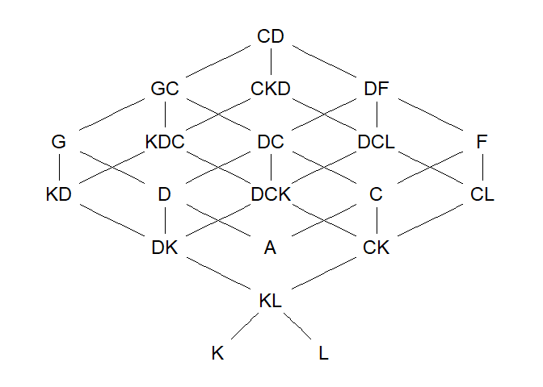

Inclusion lattice of the partial order of string role relations

##### Content

- [Introduction – Monastery novices network](https://htmlpreview.github.io/?https://github.com/mplex/networks2021/blob/main/pres/Intro_plotting.html)
- [Elementary Algebraic Structures](https://htmlpreview.github.io/?https://github.com/mplex/networks2021/blob/main/pres/Algebraic_structures.html)
- [Role Structure in Multiplex Networks](https://htmlpreview.github.io/?https://github.com/mplex/networks2021/blob/main/pres/Role_structures.html)
- [Decomposition of Role Structures](https://htmlpreview.github.io/?https://github.com/mplex/networks2021/blob/main/pres/Decomposition.html)
- [Signed Networks](https://htmlpreview.github.io/?https://github.com/mplex/networks2021/blob/main/pres/Signed_networks.html)
- [Affiliation Networks](https://htmlpreview.github.io/?https://github.com/mplex/networks2021/blob/main/pres/Affiliation_networks.html)
- [Multilevel Networks](https://htmlpreview.github.io/?https://github.com/mplex/networks2021/blob/main/pres/Multilevel_networks.html)